# Risk Factor Analysis

## Outcome Variable

**Outcome Variable:** haz

## Predictor Variables

**Intervention Variable:** parity

**Adjustment Set:**

- arm
- W_mage
- meducyrs
- feducyrs
- hhwealth_quart
- W_mhtcm
- W_mwtkg
- W_mbmi
- vagbrth
- W_nrooms
- impsan
- delta_W_mage
- delta_meducyrs
- delta_feducyrs
- delta_hhwealth_quart
- delta_W_mhtcm
- delta_W_mwtkg
- delta_W_mbmi
- delta_vagbrth
- delta_W_nrooms
- delta_impsan

## Stratifying Variables

The analysis was stratified on these variable(s):

- agecat
- studyid
- country

## Data Summary

| agecat | studyid | country | parity | n_cell | n | outcome_variable |
| --- | --- | --- | --- | --- | --- | --- |
| Birth | COHORTS | GUATEMALA | 1 | 112 | 852 | haz |
| Birth | COHORTS | GUATEMALA | 2 | 137 | 852 | haz |
| Birth | COHORTS | GUATEMALA | 3+ | 603 | 852 | haz |
| Birth | COHORTS | INDIA | 1 | 696 | 4122 | haz |
| Birth | COHORTS | INDIA | 2 | 1037 | 4122 | haz |
| Birth | COHORTS | INDIA | 3+ | 2389 | 4122 | haz |
| Birth | COHORTS | PHILIPPINES | 1 | 675 | 3050 | haz |
| Birth | COHORTS | PHILIPPINES | 2 | 687 | 3050 | haz |
| Birth | COHORTS | PHILIPPINES | 3+ | 1688 | 3050 | haz |
| Birth | GMS-Nepal | NEPAL | 1 | 211 | 696 | haz |
| Birth | GMS-Nepal | NEPAL | 2 | 180 | 696 | haz |
| Birth | GMS-Nepal | NEPAL | 3+ | 305 | 696 | haz |
| Birth | JiVitA-3 | BANGLADESH | 1 | 7456 | 22455 | haz |
| Birth | JiVitA-3 | BANGLADESH | 2 | 7615 | 22455 | haz |
| Birth | JiVitA-3 | BANGLADESH | 3+ | 7384 | 22455 | haz |
| Birth | Keneba | GAMBIA | 1 | 156 | 1407 | haz |
| Birth | Keneba | GAMBIA | 2 | 146 | 1407 | haz |
| Birth | Keneba | GAMBIA | 3+ | 1105 | 1407 | haz |
| Birth | PROVIDE | BANGLADESH | 1 | 206 | 539 | haz |
| Birth | PROVIDE | BANGLADESH | 2 | 183 | 539 | haz |
| Birth | PROVIDE | BANGLADESH | 3+ | 150 | 539 | haz |
| Birth | SAS-CompFeed | INDIA | 1 | 361 | 1252 | haz |
| Birth | SAS-CompFeed | INDIA | 2 | 289 | 1252 | haz |
| Birth | SAS-CompFeed | INDIA | 3+ | 602 | 1252 | haz |
| Birth | ZVITAMBO | ZIMBABWE | 1 | 5989 | 13874 | haz |
| Birth | ZVITAMBO | ZIMBABWE | 2 | 4144 | 13874 | haz |
| Birth | ZVITAMBO | ZIMBABWE | 3+ | 3741 | 13874 | haz |
| 6 months | COHORTS | GUATEMALA | 1 | 132 | 961 | haz |
| 6 months | COHORTS | GUATEMALA | 2 | 139 | 961 | haz |
| 6 months | COHORTS | GUATEMALA | 3+ | 690 | 961 | haz |

[output cut: 57 more lines]

The following strata were considered:

- agecat: 24 months, studyid: COHORTS, country: GUATEMALA
- agecat: 24 months, studyid: COHORTS, country: INDIA
- agecat: 24 months, studyid: COHORTS, country: PHILIPPINES
- agecat: 24 months, studyid: GMS-Nepal, country: NEPAL
- agecat: 24 months, studyid: JiVitA-3, country: BANGLADESH
- agecat: 24 months, studyid: Keneba, country: GAMBIA
- agecat: 24 months, studyid: PROVIDE, country: BANGLADESH
- agecat: 24 months, studyid: TanzaniaChild2, country: TANZANIA, UNITED REPUBLIC OF
- agecat: 24 months, studyid: ZVITAMBO, country: ZIMBABWE
- agecat: 6 months, studyid: COHORTS, country: GUATEMALA
- agecat: 6 months, studyid: COHORTS, country: INDIA
- agecat: 6 months, studyid: COHORTS, country: PHILIPPINES
- agecat: 6 months, studyid: GMS-Nepal, country: NEPAL
- agecat: 6 months, studyid: JiVitA-3, country: BANGLADESH
- agecat: 6 months, studyid: Keneba, country: GAMBIA
- agecat: 6 months, studyid: PROVIDE, country: BANGLADESH
- agecat: 6 months, studyid: SAS-CompFeed, country: INDIA
- agecat: 6 months, studyid: SAS-FoodSuppl, country: INDIA
- agecat: 6 months, studyid: TanzaniaChild2, country: TANZANIA, UNITED REPUBLIC OF
- agecat: 6 months, studyid: ZVITAMBO, country: ZIMBABWE
- agecat: Birth, studyid: COHORTS, country: GUATEMALA
- agecat: Birth, studyid: COHORTS, country: INDIA
- agecat: Birth, studyid: COHORTS, country: PHILIPPINES
- agecat: Birth, studyid: GMS-Nepal, country: NEPAL
- agecat: Birth, studyid: JiVitA-3, country: BANGLADESH
- agecat: Birth, studyid: Keneba, country: GAMBIA
- agecat: Birth, studyid: PROVIDE, country: BANGLADESH
- agecat: Birth, studyid: SAS-CompFeed, country: INDIA
- agecat: Birth, studyid: ZVITAMBO, country: ZIMBABWE

### Dropped Strata

Some strata were dropped due to rare outcomes:

- agecat: 24 months, studyid: TanzaniaChild2, country: TANZANIA, UNITED REPUBLIC OF

## Methods Detail

We’re interested in the causal parameters $E[Y_a]$ for all values of $a \in \mathcal{A}$. These parameters represent the mean outcome if, possibly contrary to fact, we intervened to set all units to have $A=a$. Under the randomization and positivity assumptions, these are identified by the statistical parameters $\psi_a=E_W[E_{Y|A,W}(Y|A=a,W)]$. In addition, we’re interested in the mean of $Y$, $E[Y]$ under no intervention (the observed mean). We will estimate these parameters by using SuperLearner to fit the relevant likelihood factors – $E_{Y|A,W}(Y|A=a,W)$ and $p(A=a|W)$, and then updating our likelihood fit using a joint TMLE.

For unadjusted analyses ($W=\{\}$), initial likelihoods were estimated using Lrnr_glm to estimate the simple $E(Y|A)$ and Lrnr_mean to estimate $p(A)$. For adjusted analyses, a small library containing Lrnr_glmnet, Lrnr_xgboost, and Lrnr_mean was used.

Having estimated these parameters, we will then use the delta method to estimate relative risks and attributable risks relative to a prespecified baseline level of $A$.

# Results Detail

## Results Plots

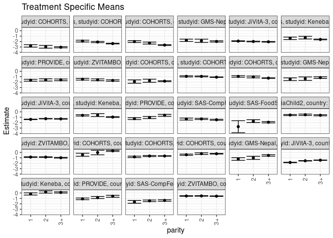

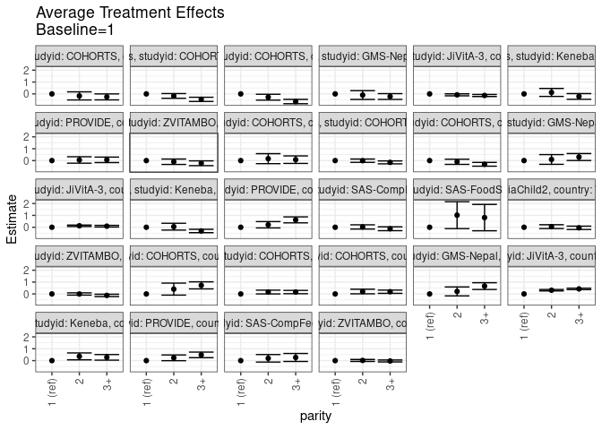

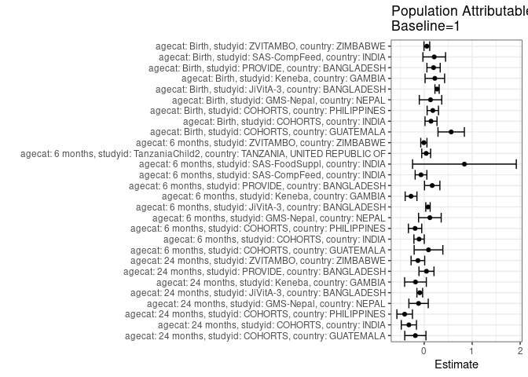

## Results Table

### Parameter: TSM

| agecat | studyid | country | intervention_level | baseline_level | estimate | ci_lower | ci_upper |
| --- | --- | --- | --- | --- | --- | --- | --- |
| Birth | COHORTS | GUATEMALA | 1 | NA | -0.4323968 | -0.7109603 | -0.1538334 |
| Birth | COHORTS | GUATEMALA | 2 | NA | -0.0268890 | -0.4476154 | 0.3938374 |
| Birth | COHORTS | GUATEMALA | 3+ | NA | 0.2900651 | 0.1872067 | 0.3929235 |
| Birth | COHORTS | INDIA | 1 | NA | -0.8194988 | -0.9491363 | -0.6898614 |
| Birth | COHORTS | INDIA | 2 | NA | -0.6583910 | -0.7501149 | -0.5666672 |
| Birth | COHORTS | INDIA | 3+ | NA | -0.6596083 | -0.7127424 | -0.6064743 |
| Birth | COHORTS | PHILIPPINES | 1 | NA | -0.4285017 | -0.5527920 | -0.3042113 |
| Birth | COHORTS | PHILIPPINES | 2 | NA | -0.2239618 | -0.3709301 | -0.0769935 |
| Birth | COHORTS | PHILIPPINES | 3+ | NA | -0.2415256 | -0.3013483 | -0.1817029 |
| Birth | GMS-Nepal | NEPAL | 1 | NA | -1.2168521 | -1.4635545 | -0.9701496 |
| Birth | GMS-Nepal | NEPAL | 2 | NA | -1.0044115 | -1.2892478 | -0.7195752 |
| Birth | GMS-Nepal | NEPAL | 3+ | NA | -0.5569562 | -0.6970932 | -0.4168192 |
| Birth | JiVitA-3 | BANGLADESH | 1 | NA | -1.8576638 | -1.9050286 | -1.8102989 |
| Birth | JiVitA-3 | BANGLADESH | 2 | NA | -1.5446773 | -1.5863300 | -1.5030245 |
| Birth | JiVitA-3 | BANGLADESH | 3+ | NA | -1.4336294 | -1.4742219 | -1.3930370 |
| Birth | Keneba | GAMBIA | 1 | NA | -0.1737216 | -0.3775580 | 0.0301148 |
| Birth | Keneba | GAMBIA | 2 | NA | 0.1834800 | -0.0232769 | 0.3902369 |
| Birth | Keneba | GAMBIA | 3+ | NA | 0.1022481 | -0.0167138 | 0.2212100 |
| Birth | PROVIDE | BANGLADESH | 1 | NA | -1.0802525 | -1.2330556 | -0.9274494 |
| Birth | PROVIDE | BANGLADESH | 2 | NA | -0.8442224 | -1.0313978 | -0.6570469 |
| Birth | PROVIDE | BANGLADESH | 3+ | NA | -0.5969341 | -0.7771790 | -0.4166892 |
| Birth | SAS-CompFeed | INDIA | 1 | NA | -1.6404168 | -1.9003938 | -1.3804398 |
| Birth | SAS-CompFeed | INDIA | 2 | NA | -1.4453712 | -1.5926818 | -1.2980607 |
| Birth | SAS-CompFeed | INDIA | 3+ | NA | -1.3746945 | -1.5177537 | -1.2316352 |
| Birth | ZVITAMBO | ZIMBABWE | 1 | NA | -0.5555529 | -0.6193283 | -0.4917776 |
| Birth | ZVITAMBO | ZIMBABWE | 2 | NA | -0.5409296 | -0.5941451 | -0.4877142 |
| Birth | ZVITAMBO | ZIMBABWE | 3+ | NA | -0.5861287 | -0.6391070 | -0.5331504 |
| 6 months | COHORTS | GUATEMALA | 1 | NA | -1.9053858 | -2.2113691 | -1.5994025 |
| 6 months | COHORTS | GUATEMALA | 2 | NA | -1.7437982 | -2.0328655 | -1.4547309 |
| 6 months | COHORTS | GUATEMALA | 3+ | NA | -1.8269353 | -1.9127844 | -1.7410862 |

[output cut: 54 more lines]

### Parameter: E(Y)

| agecat | studyid | country | intervention_level | baseline_level | estimate | ci_lower | ci_upper |
| --- | --- | --- | --- | --- | --- | --- | --- |
| Birth | COHORTS | GUATEMALA | NA | NA | 0.1297300 | 0.0458017 | 0.2136584 |
| Birth | COHORTS | INDIA | NA | NA | -0.6773241 | -0.7124609 | -0.6421873 |
| Birth | COHORTS | PHILIPPINES | NA | NA | -0.2490492 | -0.2880580 | -0.2100404 |
| Birth | GMS-Nepal | NEPAL | NA | NA | -1.0851580 | -1.1651811 | -1.0051350 |
| Birth | JiVitA-3 | BANGLADESH | NA | NA | -1.5894148 | -1.6086362 | -1.5701935 |
| Birth | Keneba | GAMBIA | NA | NA | 0.0483298 | -0.0182746 | 0.1149342 |
| Birth | PROVIDE | BANGLADESH | NA | NA | -0.8851020 | -0.9601332 | -0.8100709 |
| Birth | SAS-CompFeed | INDIA | NA | NA | -1.4314217 | -1.5099245 | -1.3529189 |
| Birth | ZVITAMBO | ZIMBABWE | NA | NA | -0.5003222 | -0.5208673 | -0.4797770 |
| 6 months | COHORTS | GUATEMALA | NA | NA | -1.8157336 | -1.8837688 | -1.7476985 |
| 6 months | COHORTS | INDIA | NA | NA | -1.0455022 | -1.0805318 | -1.0104727 |
| 6 months | COHORTS | PHILIPPINES | NA | NA | -1.1405724 | -1.1824954 | -1.0986493 |
| 6 months | GMS-Nepal | NEPAL | NA | NA | -1.3508392 | -1.4290633 | -1.2726152 |
| 6 months | JiVitA-3 | BANGLADESH | NA | NA | -1.3130932 | -1.3362359 | -1.2899505 |
| 6 months | Keneba | GAMBIA | NA | NA | -0.9239386 | -0.9768148 | -0.8710623 |
| 6 months | PROVIDE | BANGLADESH | NA | NA | -1.0916915 | -1.1661176 | -1.0172654 |
| 6 months | SAS-CompFeed | INDIA | NA | NA | -1.4018563 | -1.4810585 | -1.3226541 |
| 6 months | SAS-FoodSuppl | INDIA | NA | NA | -1.8986842 | -2.0118892 | -1.7854792 |
| 6 months | TanzaniaChild2 | TANZANIA, UNITED REPUBLIC OF | NA | NA | -0.5432778 | -0.5926218 | -0.4939338 |
| 6 months | ZVITAMBO | ZIMBABWE | NA | NA | -0.8679886 | -0.8935535 | -0.8424236 |
| 24 months | COHORTS | GUATEMALA | NA | NA | -2.9905921 | -3.0548289 | -2.9263553 |
| 24 months | COHORTS | INDIA | NA | NA | -2.2397574 | -2.2808841 | -2.1986307 |
| 24 months | COHORTS | PHILIPPINES | NA | NA | -2.4141145 | -2.4590818 | -2.3691473 |
| 24 months | GMS-Nepal | NEPAL | NA | NA | -1.8874180 | -1.9728588 | -1.8019773 |
| 24 months | JiVitA-3 | BANGLADESH | NA | NA | -2.0136481 | -2.0413552 | -1.9859409 |
| 24 months | Keneba | GAMBIA | NA | NA | -1.5883084 | -1.6443765 | -1.5322402 |
| 24 months | PROVIDE | BANGLADESH | NA | NA | -1.6024221 | -1.6857420 | -1.5191023 |
| 24 months | ZVITAMBO | ZIMBABWE | NA | NA | -1.6059640 | -1.6629797 | -1.5489484 |

### Parameter: ATE

| agecat | studyid | country | intervention_level | baseline_level | estimate | ci_lower | ci_upper |
| --- | --- | --- | --- | --- | --- | --- | --- |
| Birth | COHORTS | GUATEMALA | 1 | 1 | 0.0000000 | 0.0000000 | 0.0000000 |
| Birth | COHORTS | GUATEMALA | 2 | 1 | 0.4055079 | -0.1002808 | 0.9112966 |
| Birth | COHORTS | GUATEMALA | 3+ | 1 | 0.7224620 | 0.4252552 | 1.0196688 |
| Birth | COHORTS | INDIA | 1 | 1 | 0.0000000 | 0.0000000 | 0.0000000 |
| Birth | COHORTS | INDIA | 2 | 1 | 0.1611078 | 0.0025746 | 0.3196410 |
| Birth | COHORTS | INDIA | 3+ | 1 | 0.1598905 | 0.0200601 | 0.2997209 |
| Birth | COHORTS | PHILIPPINES | 1 | 1 | 0.0000000 | 0.0000000 | 0.0000000 |
| Birth | COHORTS | PHILIPPINES | 2 | 1 | 0.2045398 | 0.0125793 | 0.3965004 |
| Birth | COHORTS | PHILIPPINES | 3+ | 1 | 0.1869761 | 0.0495150 | 0.3244371 |
| Birth | GMS-Nepal | NEPAL | 1 | 1 | 0.0000000 | 0.0000000 | 0.0000000 |
| Birth | GMS-Nepal | NEPAL | 2 | 1 | 0.2124405 | -0.1639811 | 0.5888622 |
| Birth | GMS-Nepal | NEPAL | 3+ | 1 | 0.6598958 | 0.3746262 | 0.9451655 |
| Birth | JiVitA-3 | BANGLADESH | 1 | 1 | 0.0000000 | 0.0000000 | 0.0000000 |
| Birth | JiVitA-3 | BANGLADESH | 2 | 1 | 0.3129865 | 0.2517603 | 0.3742128 |
| Birth | JiVitA-3 | BANGLADESH | 3+ | 1 | 0.4240344 | 0.3643969 | 0.4836719 |
| Birth | Keneba | GAMBIA | 1 | 1 | 0.0000000 | 0.0000000 | 0.0000000 |
| Birth | Keneba | GAMBIA | 2 | 1 | 0.3572016 | 0.0673860 | 0.6470171 |
| Birth | Keneba | GAMBIA | 3+ | 1 | 0.2759696 | 0.0403731 | 0.5115662 |
| Birth | PROVIDE | BANGLADESH | 1 | 1 | 0.0000000 | 0.0000000 | 0.0000000 |
| Birth | PROVIDE | BANGLADESH | 2 | 1 | 0.2360301 | -0.0050927 | 0.4771529 |
| Birth | PROVIDE | BANGLADESH | 3+ | 1 | 0.4833184 | 0.2471463 | 0.7194905 |
| Birth | SAS-CompFeed | INDIA | 1 | 1 | 0.0000000 | 0.0000000 | 0.0000000 |
| Birth | SAS-CompFeed | INDIA | 2 | 1 | 0.1950455 | -0.1219996 | 0.5120907 |
| Birth | SAS-CompFeed | INDIA | 3+ | 1 | 0.2657223 | -0.0726825 | 0.6041271 |
| Birth | ZVITAMBO | ZIMBABWE | 1 | 1 | 0.0000000 | 0.0000000 | 0.0000000 |
| Birth | ZVITAMBO | ZIMBABWE | 2 | 1 | 0.0146233 | -0.0682814 | 0.0975280 |
| Birth | ZVITAMBO | ZIMBABWE | 3+ | 1 | -0.0305758 | -0.1133889 | 0.0522374 |
| 6 months | COHORTS | GUATEMALA | 1 | 1 | 0.0000000 | 0.0000000 | 0.0000000 |
| 6 months | COHORTS | GUATEMALA | 2 | 1 | 0.1615876 | -0.2595337 | 0.5827089 |
| 6 months | COHORTS | GUATEMALA | 3+ | 1 | 0.0784505 | -0.2393213 | 0.3962223 |

[output cut: 54 more lines]

### Parameter: PAR

| agecat | studyid | country | intervention_level | baseline_level | estimate | ci_lower | ci_upper |
| --- | --- | --- | --- | --- | --- | --- | --- |
| Birth | COHORTS | GUATEMALA | 1 | NA | 0.5621269 | 0.2872395 | 0.8370143 |
| Birth | COHORTS | INDIA | 1 | NA | 0.1421747 | 0.0173236 | 0.2670259 |
| Birth | COHORTS | PHILIPPINES | 1 | NA | 0.1794525 | 0.0610561 | 0.2978489 |
| Birth | GMS-Nepal | NEPAL | 1 | NA | 0.1316940 | -0.1024161 | 0.3658041 |
| Birth | JiVitA-3 | BANGLADESH | 1 | NA | 0.2682490 | 0.2239206 | 0.3125774 |
| Birth | Keneba | GAMBIA | 1 | NA | 0.2220514 | 0.0185940 | 0.4255087 |
| Birth | PROVIDE | BANGLADESH | 1 | NA | 0.1951505 | 0.0568907 | 0.3334102 |
| Birth | SAS-CompFeed | INDIA | 1 | NA | 0.2089950 | -0.0271787 | 0.4451688 |
| Birth | ZVITAMBO | ZIMBABWE | 1 | NA | 0.0552308 | -0.0047068 | 0.1151683 |
| 6 months | COHORTS | GUATEMALA | 1 | NA | 0.0896522 | -0.2095688 | 0.3888732 |
| 6 months | COHORTS | INDIA | 1 | NA | -0.1066896 | -0.2143202 | 0.0009411 |
| 6 months | COHORTS | PHILIPPINES | 1 | NA | -0.1899906 | -0.3289301 | -0.0510512 |
| 6 months | GMS-Nepal | NEPAL | 1 | NA | 0.1186050 | -0.1170738 | 0.3542839 |
| 6 months | JiVitA-3 | BANGLADESH | 1 | NA | 0.0784742 | 0.0328752 | 0.1240731 |
| 6 months | Keneba | GAMBIA | 1 | NA | -0.2741288 | -0.3969949 | -0.1512627 |
| 6 months | PROVIDE | BANGLADESH | 1 | NA | 0.1667707 | 0.0065856 | 0.3269557 |
| 6 months | SAS-CompFeed | INDIA | 1 | NA | -0.0664109 | -0.1884110 | 0.0555892 |
| 6 months | SAS-FoodSuppl | INDIA | 1 | NA | 0.8384586 | -0.2422291 | 1.9191464 |
| 6 months | TanzaniaChild2 | TANZANIA, UNITED REPUBLIC OF | 1 | NA | 0.0412571 | -0.0513555 | 0.1338698 |
| 6 months | ZVITAMBO | ZIMBABWE | 1 | NA | -0.0070032 | -0.0714373 | 0.0574308 |
| 24 months | COHORTS | GUATEMALA | 1 | NA | -0.1842568 | -0.4050245 | 0.0365109 |
| 24 months | COHORTS | INDIA | 1 | NA | -0.3193844 | -0.4776187 | -0.1611502 |
| 24 months | COHORTS | PHILIPPINES | 1 | NA | -0.4070578 | -0.5690664 | -0.2450491 |
| 24 months | GMS-Nepal | NEPAL | 1 | NA | -0.1174627 | -0.3193512 | 0.0844257 |
| 24 months | JiVitA-3 | BANGLADESH | 1 | NA | -0.0924641 | -0.1517502 | -0.0331780 |
| 24 months | Keneba | GAMBIA | 1 | NA | -0.1818224 | -0.4080539 | 0.0444091 |
| 24 months | PROVIDE | BANGLADESH | 1 | NA | 0.0474830 | -0.1090564 | 0.2040224 |
| 24 months | ZVITAMBO | ZIMBABWE | 1 | NA | -0.1314210 | -0.2738402 | 0.0109983 |